# Interaction Between Tumor Features and the Probability of Malignancy in Breast Cancer

Amanda Flores

2024-08-14

# Dataset and Analysis

- The data I selected is from the Breast Cancer Wisconsin (Diagnostic) Database, as utilized in the paper “Machine Learning Approaches for Cancer Detection.” This data set contains features extracted from digitized images of fine needle aspirate (FNA) samples of breast masses, specifically describing the characteristics of the cell nuclei.
- Despite being an old and classic dataset, it includes a comprehensive range of tumor characteristics and it is a good example that allows for demonstration of statistical and visualization methods.

# Reading Data

```r
#Importing necessary libraries
library(dplyr)
```

```r
library(tidyr)
library(ggplot2)
library(reshape2)
library(GGally)
library(RColorBrewer)

#Reading in the .csv file.
setwd("~/Desktop/Final Project R")
data <- read.csv("breast_cancer.csv")

#checking the first few rows
head(data)
```

```
##         id diagnosis radius_mean texture_mean perimeter_mean area_mean
## 1   842302         M       17.99        10.38         122.80    1001.0
## 2   842517         M       20.57        17.77         132.90    1326.0
## 3 84300903         M       19.69        21.25         130.00    1203.0
## 4 84348301         M       11.42        20.38          77.58     386.1
## 5 84358402         M       20.29        14.34         135.10    1297.0
## 6   843786         M       12.45        15.70          82.57     477.1
##   smoothness_mean compactness_mean concavity_mean concave.points_mean
## 1         0.11840          0.27760         0.3001             0.14710
## 2         0.08474          0.07864         0.0869             0.07017
## 3         0.10960          0.15990         0.1974             0.12790
## 4         0.14250          0.28390         0.2414             0.10520
## 5         0.10030          0.13280         0.1980             0.10430
## 6         0.12780          0.17000         0.1578             0.08089
##   symmetry_mean fractal_dimension_mean radius_se texture_se perimeter_se
```

[output cut: 34 more lines]

# Cleaning

```r
#The following code was used to check missing values and removing the index column
#Checked the missing values
anyNA(data)
# Counting missing values per column
missing_counts <- colSums(is.na(data))
print(missing_counts)

# Checked rows with missing values
missing_rows <- data[!complete.cases(data), ]
print(missing_rows)

#Removed Index column
if ("X" %in% names(data)) {
  data$X <- NULL
}
```

[output not shown]

-I checked the structure of the dataset to understand the type of data, count the number of missing values per column and removed the unnecessary index column (`X`).

# Data Exploration

- I used ggplot2 to visualize the count of malignant vs benign tumors in the dataset to have an overall balance of diagnosis.

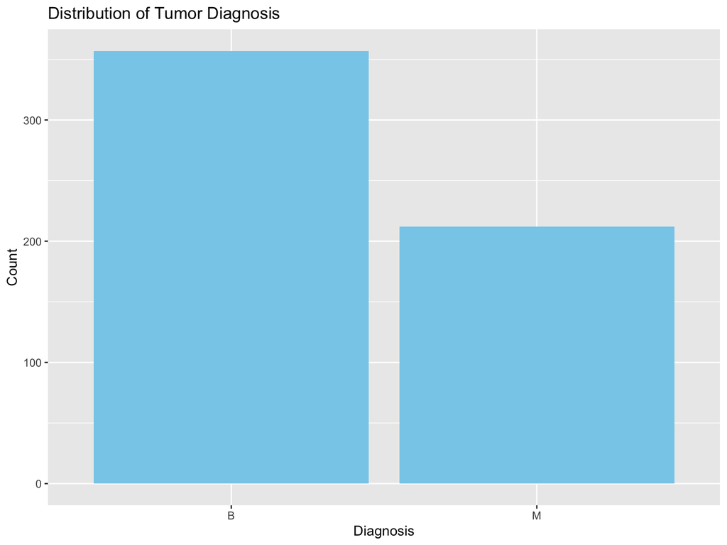

```r
#I wanted to check the proportion of malignant and benign tumors in the dataset
library(ggplot2)
ggplot(data, aes(x = diagnosis)) +
  geom_bar(fill = "skyblue") +
  labs(title = "Distribution of Tumor Diagnosis",
       x = "Diagnosis",
       y = "Count")
```

# Analysis

- This feature analysis was made to compare the distribution of the radius_mean feature between malignant and benign tumors. Boxplots highlight differences in central tendency and variability, showing how radius_mean differs by diagnosis

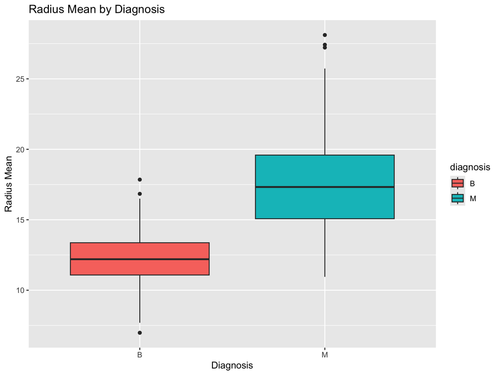

```r
#Feature Analysis to compare the distribution of radius mean between malignant and benign tumors
ggplot(data, aes(x = diagnosis, y = radius_mean, fill = diagnosis)) +
  geom_boxplot() +
  labs(title = "Radius Mean by Diagnosis",
       x = "Diagnosis",
       y = "Radius Mean")
```

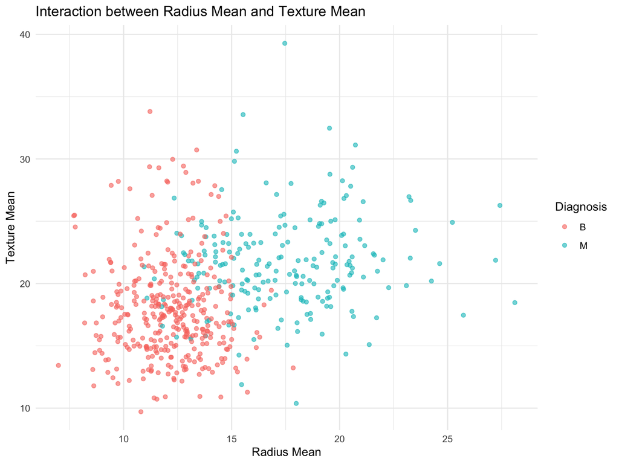

```r
#interaction plot
ggplot(data, aes(x = radius_mean, y = texture_mean, color = diagnosis)) +
  geom_point(alpha = 0.6) +
  labs(title = "Interaction between Radius Mean and Texture Mean",
       x = "Radius Mean",
       y = "Texture Mean",
       color = "Diagnosis") +
  theme_minimal()
```

# Box Plots of Key Features

- The box plots show the distribution of radius_mean, texture_mean, and area_mean features by diagnosis and provides insights into how these features vary between malignant and benign tumors.

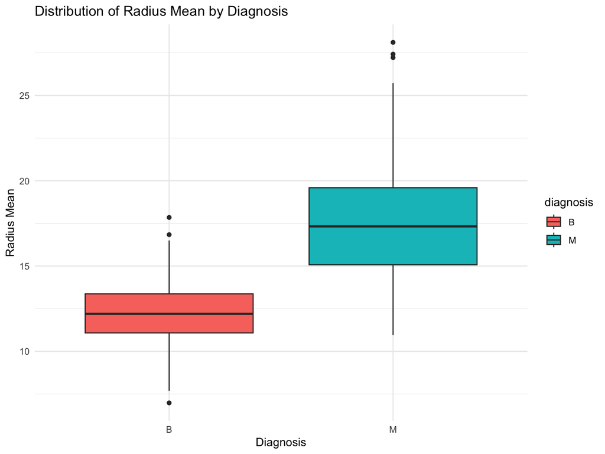

```r
# Boxplots
boxplot_radius_mean <- ggplot(data, aes(x = diagnosis, y = radius_mean, fill = diagnosis)) +
  geom_boxplot() +
  labs(title = "Distribution of Radius Mean by Diagnosis",
       x = "Diagnosis",
       y = "Radius Mean") +
  theme_minimal()

boxplot_texture_mean <- ggplot(data, aes(x = diagnosis, y = texture_mean, fill = diagnosis)) +
  geom_boxplot() +
  labs(title = "Distribution of Texture Mean by Diagnosis",
       x = "Diagnosis",
       y = "Texture Mean") +
  theme_minimal()

boxplot_area_mean <- ggplot(data, aes(x = diagnosis, y = area_mean, fill = diagnosis)) +
  geom_boxplot() +
  labs(title = "Distribution of Area Mean by Diagnosis",
       x = "Diagnosis",
       y = "Area Mean") +
  theme_minimal()
# Print the box plots
print(boxplot_radius_mean)
```

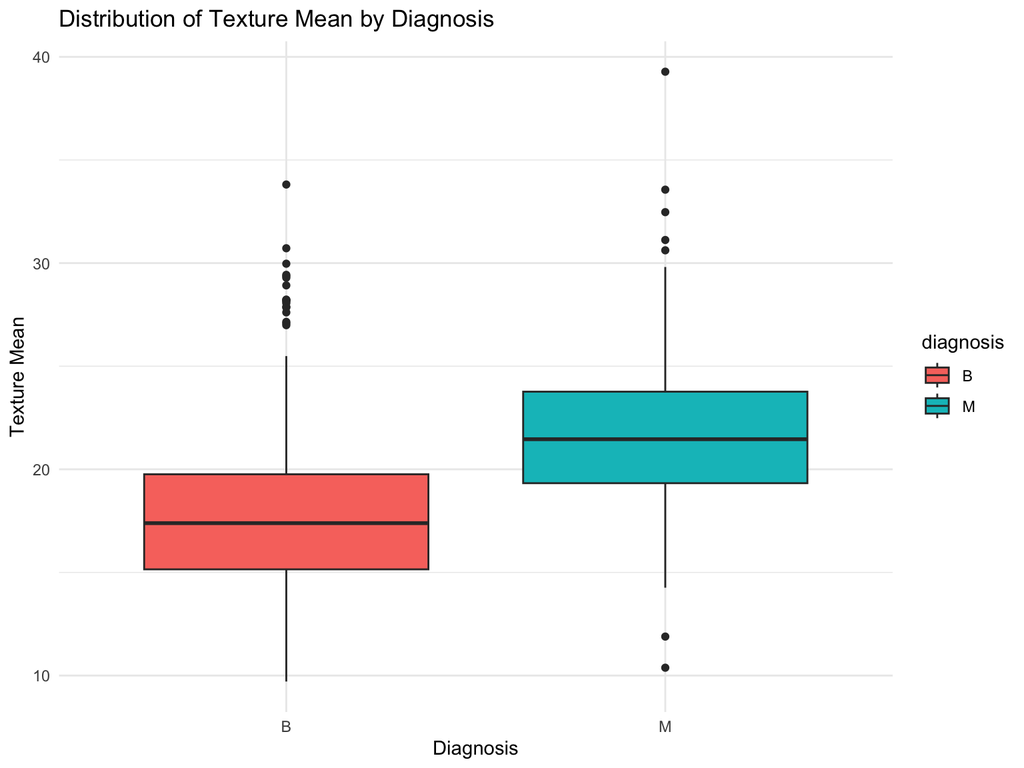

```r
print(boxplot_texture_mean)
```

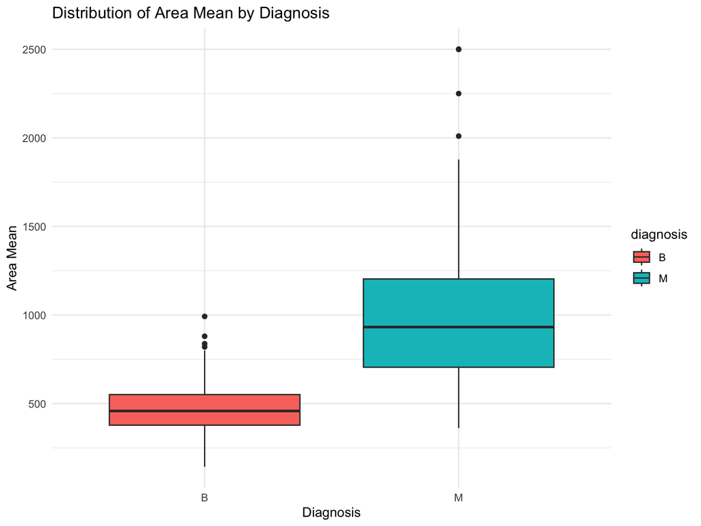

```r
print(boxplot_area_mean)
```

# Pair Plot of Key Features

- The Pair Plot shows clear grouping of malignant and benign cases

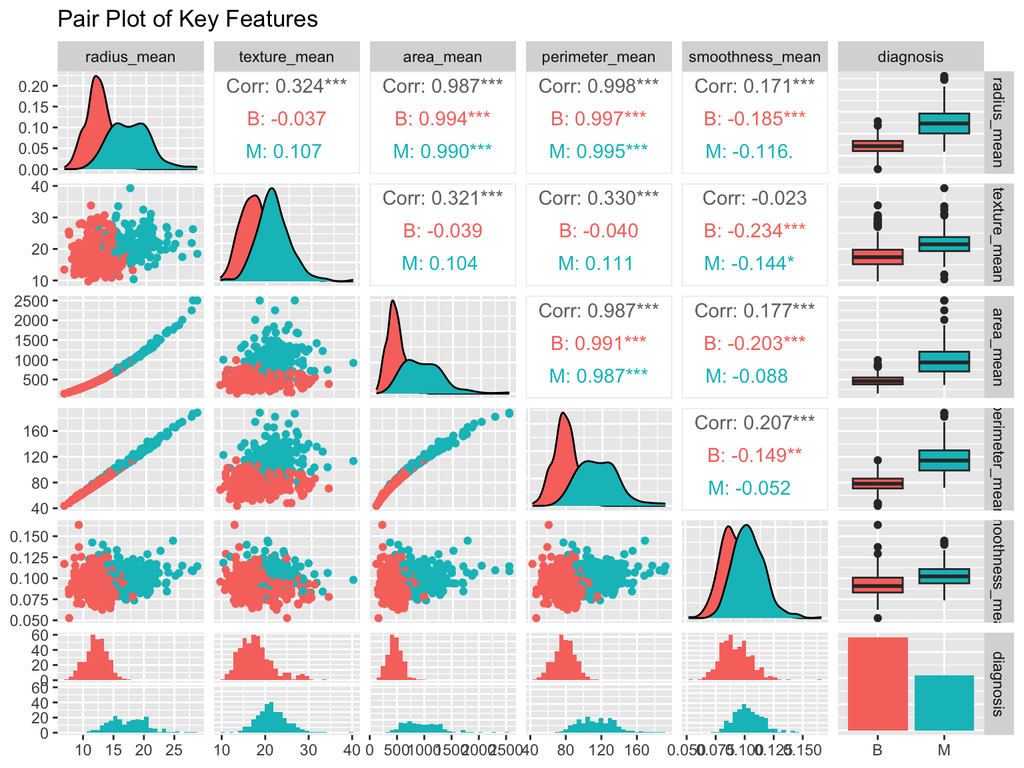

```r
key_features <- data[, c("radius_mean", "texture_mean", "area_mean", "perimeter_mean", "smoothness_mean")]
key_features$diagnosis <- data$diagnosis

pair_plot <- ggpairs(key_features, aes(color = diagnosis)) +
  labs(title = "Pair Plot of Key Features")
print(pair_plot)
```

- The pair plot visualizes the relationships between key features in the dataset, focusing on how they correlate with the tumor diagnosis (malignant vs. benign). Since the dataset includes features like radius_mean, texture_mean, area_mean, perimeter_mean, and smoothness_mean, we can see the distribution of individual features for malignant (M) and benign (B) tumors that shows that Malignant tumors tend to have higher values for features like radius_mean, area_mean, and perimeter_mean compared to benign tumors.

# Discussion and Future Directions

**Discussion**

- Based on the predictors used (radius, area and perimeter means) we could observe that malignant tumors consistently show higher feature values.
- The dataset was found to be clean with no missing values, making it a reliable source for the analysis. The correlations observed between certain features highlight the underlying biological relationships but also suggest a need for careful consideration in model building including more updates parameters.

**Limitations**

- Aging Dataset: The Breast Cancer Wisconsin (Diagnostic) dataset is relatively old and diagnostic methods were updated. As such, it may not fully represent the current state of breast cancer diagnosis and treatment. Advances in imaging technology, diagnostic methods, and a better understanding of cancer biology have led to new features and markers that are not captured in this dataset and would be good to use a new dataset and do a comparison with the one used in this analysis.
- Lack of Clinical Data: The dataset focuses on morphological features derived from cell nuclei images but lacks detailed clinical data such as patient age, family history, genetic information, and treatment outcomes. This limits the scope of the analysis and prevents a comprehensive understanding of how these features interact with clinical factors.

**Future Directions**

- Analyze a recent dataset: Incorporate more recent datasets that contains similar predictors with current diagnostic technologies and population diversity and do a comparison. Modern datasets would provide more relevant and accurate insights, potentially uncovering new predictive features that are not present in the older dataset.
- Trying to explore Predictive Models: The insights gained from this analysis can be used as a foundation for developing predictive models such as logistic regression or decision trees could be applied to build models that predict tumor diagnosis with better accuracy.

# References

- Nuclear feature extraction for breast tumor diagnosis By W. Street, W. Wolberg, O. Mangasarian. 1993 Published in Electronic imaging
- Sharma, A., Kulshrestha, S., & Daniel, S. (2018). Machine learning approaches for cancer detection. International Journal of Engineering and Manufacturing, 8(3).
- Abunasser, B. S., AL-Hiealy, M. R. J., Zaqout, I. S., & Abu-Naser, S. S. (2022). Breast cancer detection and classification using deep learning Xception algorithm. International Journal of Advanced Computer Science and Applications, 13(7). https://doi.org/10.14569/IJACSA.2022.0130729
- Dua, D., & Graff, C. (1995). Breast Cancer Wisconsin (Diagnostic) Data Set. UCI Machine Learning Repository. Retrieved from https://archive.ics.uci.edu/dataset/17/breast+cancer+wisconsin+diagnostic